# Project_G12

#### Liệt kê tổng số NA của từng biến

```r
sapply(df,function(x) sum(is.na(x)))
```

```
##          Date      Location       MinTemp       MaxTemp      Rainfall
##             0             0          2760          2555          5037
##   Evaporation      Sunshine   WindGustDir WindGustSpeed    WindDir9am
##         96586        104989         14477         14376         14738
##    WindDir3pm  WindSpeed9am  WindSpeed3pm   Humidity9am   Humidity3pm
##          7729          3351          6406          3828          7472
##   Pressure9am   Pressure3pm      Cloud9am      Cloud3pm       Temp9am
##         21098         21089         80359         86239          2832
##       Temp3pm     RainToday       RISK_MM  RainTomorrow
##          6472          5037          5038          5038
```

#### Trực quan hóa các giá trị Missing

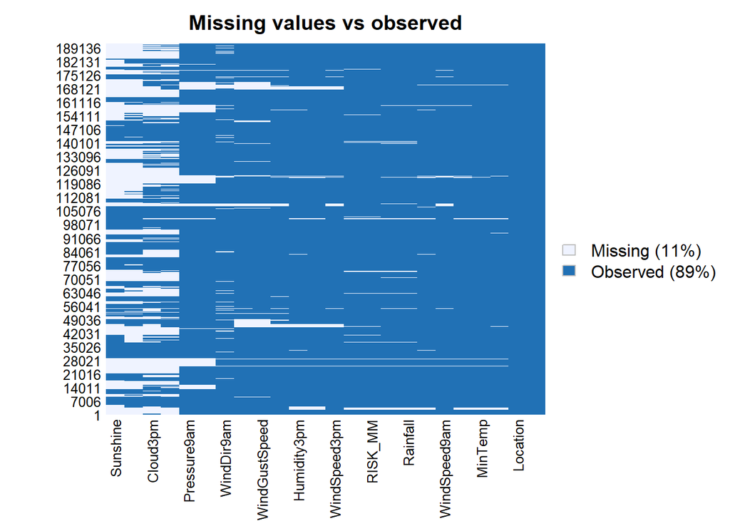

```r
missmap(df, main = "Missing values vs observed")
```

#### Sắp xếp tập dữ liệu tăng dần theo biến “DATE” và hiển thị vài dòng sau khi sắp xếp

```r
df <- sqldf('select * from df order by Date ASC')
head(df)
```

```
##         Date Location MinTemp MaxTemp Rainfall Evaporation Sunshine WindGustDir
## 1 2007-11-01 Canberra     8.0    24.3      0.0         3.4      6.3          NW
## 2 2007-11-02 Canberra    14.0    26.9      3.6         4.4      9.7         ENE
## 3 2007-11-03 Canberra    13.7    23.4      3.6         5.8      3.3          NW
## 4 2007-11-04 Canberra    13.3    15.5     39.8         7.2      9.1          NW
## 5 2007-11-05 Canberra     7.6    16.1      2.8         5.6     10.6         SSE
## 6 2007-11-06 Canberra     6.2    16.9      0.0         5.8      8.2          SE
##   WindGustSpeed WindDir9am WindDir3pm WindSpeed9am WindSpeed3pm Humidity9am
## 1            30         SW         NW            6           20          68
## 2            39          E          W            4           17          80
## 3            85          N        NNE            6            6          82
## 4            54        WNW          W           30           24          62
## 5            50        SSE        ESE           20           28          68
## 6            44         SE          E           20           24          70
##   Humidity3pm Pressure9am Pressure3pm Cloud9am Cloud3pm Temp9am Temp3pm
## 1          29      1019.7      1015.0        7        7    14.4    23.6
## 2          36      1012.4      1008.4        5        3    17.5    25.7
## 3          69      1009.5      1007.2        8        7    15.4    20.2
## 4          56      1005.5      1007.0        2        7    13.5    14.1
## 5          49      1018.3      1018.5        7        7    11.1    15.4
## 6          57      1023.8      1021.7        7        5    10.9    14.8
##   RainToday RISK_MM RainTomorrow
## 1        No     3.6          Yes
## 2       Yes     3.6          Yes
## 3       Yes    39.8          Yes
## 4       Yes     2.8          Yes
## 5       Yes     0.0           No
## 6        No     0.2           No
```

#### Loại bỏ các giá trị Missing và chuẩn hóa hai biến “Pressure9am” và “Pressure3am” theo log

```r
df <- df[complete.cases(df),] # loại bỏ các giá trị missing value
df$Pressure9am <- log(df$Pressure9am) #Normalization
df$Pressure3pm <- log(df$Pressure3pm)
```

#### Chuyển một số biến sang kiểu factor

```r
df$RainTomorrow <- as.factor(df$RainTomorrow)
df$RainToday <- as.factor((df$RainToday))
df$WindDir3pm <- as.factor(df$WindDir3pm)
df$WindDir9am <- as.factor(df$WindDir9am)
df$WindGustDir <- as.factor(df$WindGustDir)
df$Location <- as.factor(df$Location)
```

#### Loại bỏ cột 23 là biến lượng mưa vì không phù hợp để làm biến dự đoán

```r
df<- df[,-23]
head(df)
```

```
##         Date Location MinTemp MaxTemp Rainfall Evaporation Sunshine WindGustDir
## 1 2007-11-01 Canberra     8.0    24.3      0.0         3.4      6.3          NW
## 2 2007-11-02 Canberra    14.0    26.9      3.6         4.4      9.7         ENE
## 3 2007-11-03 Canberra    13.7    23.4      3.6         5.8      3.3          NW
## 4 2007-11-04 Canberra    13.3    15.5     39.8         7.2      9.1          NW
## 5 2007-11-05 Canberra     7.6    16.1      2.8         5.6     10.6         SSE
## 6 2007-11-06 Canberra     6.2    16.9      0.0         5.8      8.2          SE
##   WindGustSpeed WindDir9am WindDir3pm WindSpeed9am WindSpeed3pm Humidity9am
## 1            30         SW         NW            6           20          68
## 2            39          E          W            4           17          80
## 3            85          N        NNE            6            6          82
## 4            54        WNW          W           30           24          62
## 5            50        SSE        ESE           20           28          68
## 6            44         SE          E           20           24          70
##   Humidity3pm Pressure9am Pressure3pm Cloud9am Cloud3pm Temp9am Temp3pm
## 1          29    6.927264    6.922644        7        7    14.4    23.6
## 2          36    6.920079    6.916120        5        3    17.5    25.7
## 3          69    6.917210    6.914929        8        7    15.4    20.2
## 4          56    6.913240    6.914731        2        7    13.5    14.1
## 5          49    6.925890    6.926086        7        7    11.1    15.4
## 6          57    6.931276    6.929223        7        5    10.9    14.8
##   RainToday RainTomorrow
## 1        No          Yes
## 2       Yes          Yes
## 3       Yes          Yes
## 4       Yes          Yes
## 5       Yes           No
## 6        No           No
```

#### Kiểm tra dữ liệu đã được sắp xếp và kiểu dữ liệu đã được chuyển đổi

```r
glimpse(df)
```

```
## Rows: 64,229
## Columns: 23
## $ Date          <chr> "2007-11-01", "2007-11-02", "2007-11-03", "2007-11-04", ~
## $ Location      <fct> Canberra, Canberra, Canberra, Canberra, Canberra, Canber~
## $ MinTemp       <dbl> 8.0, 14.0, 13.7, 13.3, 7.6, 6.2, 6.1, 8.3, 8.8, 8.4, 9.1~
## $ MaxTemp       <dbl> 24.3, 26.9, 23.4, 15.5, 16.1, 16.9, 18.2, 17.0, 19.5, 22~
## $ Rainfall      <dbl> 0.0, 3.6, 3.6, 39.8, 2.8, 0.0, 0.2, 0.0, 0.0, 16.2, 0.0,~
## $ Evaporation   <dbl> 3.4, 4.4, 5.8, 7.2, 5.6, 5.8, 4.2, 5.6, 4.0, 5.4, 4.2, 7~
## $ Sunshine      <dbl> 6.3, 9.7, 3.3, 9.1, 10.6, 8.2, 8.4, 4.6, 4.1, 7.7, 11.9,~
## $ WindGustDir   <fct> NW, ENE, NW, NW, SSE, SE, SE, E, S, E, N, E, WNW, NW, NW~
## $ WindGustSpeed <int> 30, 39, 85, 54, 50, 44, 43, 41, 48, 31, 30, 41, 30, 44, ~
## $ WindDir9am    <fct> SW, E, N, WNW, SSE, SE, SE, SE, E, S, SE, E, S, WNW, S, ~
## $ WindDir3pm    <fct> NW, W, NNE, W, ESE, E, ESE, E, ENE, ESE, NW, NW, NW, W, ~
## $ WindSpeed9am  <int> 6, 4, 6, 30, 20, 20, 19, 11, 19, 7, 6, 2, 6, 7, 6, 7, 6,~
## $ WindSpeed3pm  <int> 20, 17, 6, 24, 28, 24, 26, 24, 17, 6, 9, 15, 7, 20, 20, ~
## $ Humidity9am   <int> 68, 80, 82, 62, 68, 70, 63, 65, 70, 82, 74, 54, 62, 67, ~
## $ Humidity3pm   <int> 29, 36, 69, 56, 49, 57, 47, 57, 48, 32, 34, 35, 29, 20, ~
## $ Pressure9am   <dbl> 6.927264, 6.920079, 6.917210, 6.913240, 6.925890, 6.9312~
## $ Pressure3pm   <dbl> 6.922644, 6.916120, 6.914929, 6.914731, 6.926086, 6.9292~
## $ Cloud9am      <int> 7, 5, 8, 2, 7, 7, 4, 6, 7, 7, 1, 0, 0, 1, 0, 0, 7, 1, 1,~
## $ Cloud3pm      <int> 7, 3, 7, 7, 7, 5, 6, 7, 7, 1, 2, 3, 1, 4, 1, 3, 6, 5, 3,~
## $ Temp9am       <dbl> 14.4, 17.5, 15.4, 13.5, 11.1, 10.9, 12.4, 12.1, 14.1, 13~
## $ Temp3pm       <dbl> 23.6, 25.7, 20.2, 14.1, 15.4, 14.8, 17.3, 15.5, 18.9, 21~
## $ RainToday     <fct> No, Yes, Yes, Yes, Yes, No, No, No, No, Yes, No, No, No,~
## $ RainTomorrow  <fct> Yes, Yes, Yes, Yes, No, No, No, No, Yes, No, No, No, No,~
```

#### Kiểm tra số lượng Missing value còn trong tập dữ liệu

```r
numdf <- select_if(df, is.numeric)
sum(is.na(numdf))
```

```
## [1] 0
```

#### Tìm ra một số biến có độ tương quan cao

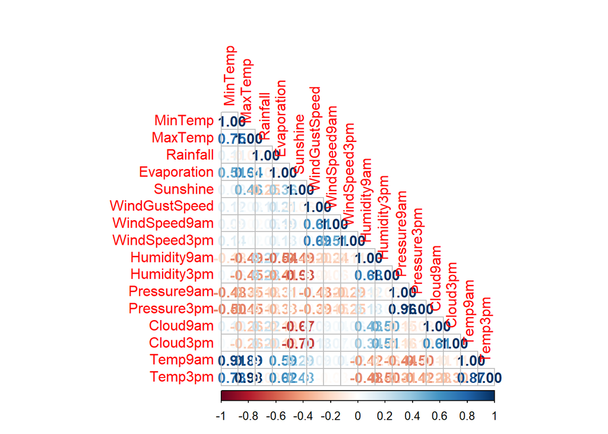

```r
corrplot::corrplot(cor(numdf), method = "number", type = "lower")
```

#### Tiến hành loại bỏ một số biến có độ tương quan cao hoặc không phù hợp

```r
df <- df[,- c(1,2,17,20,21)]
head(df)
```

```
##   MinTemp MaxTemp Rainfall Evaporation Sunshine WindGustDir WindGustSpeed
## 1     8.0    24.3      0.0         3.4      6.3          NW            30
## 2    14.0    26.9      3.6         4.4      9.7         ENE            39
## 3    13.7    23.4      3.6         5.8      3.3          NW            85
## 4    13.3    15.5     39.8         7.2      9.1          NW            54
## 5     7.6    16.1      2.8         5.6     10.6         SSE            50
## 6     6.2    16.9      0.0         5.8      8.2          SE            44
##   WindDir9am WindDir3pm WindSpeed9am WindSpeed3pm Humidity9am Humidity3pm
## 1         SW         NW            6           20          68          29
## 2          E          W            4           17          80          36
## 3          N        NNE            6            6          82          69
## 4        WNW          W           30           24          62          56
## 5        SSE        ESE           20           28          68          49
## 6         SE          E           20           24          70          57
##   Pressure9am Cloud9am Cloud3pm RainToday RainTomorrow
## 1    6.927264        7        7        No          Yes
## 2    6.920079        5        3       Yes          Yes
## 3    6.917210        8        7       Yes          Yes
## 4    6.913240        2        7       Yes          Yes
## 5    6.925890        7        7       Yes           No
## 6    6.931276        7        5        No           No
```

#### Vẽ biểu đồ thể hiện sự chênh lệch giữa hai nhãn “Yes” và “No” của biến kết quả

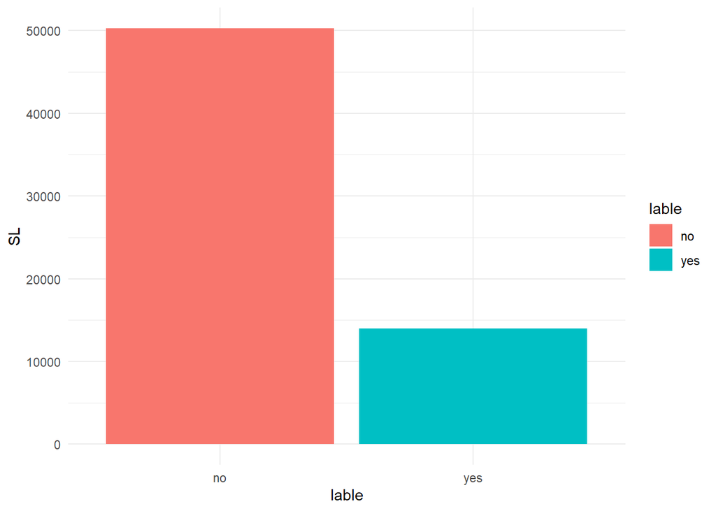

```r
yes <- 0
no <- 0
for (i in c(1:nrow(df))) {
  if(df$RainTomorrow[i]=="Yes")
    yes<- yes +1
  else
    no <- no +1
}
SL <- c(yes,no)
lable <- c('yes','no')
c <- data.frame(SL,lable)
#library(ggplot2)
ggplot(data = c,aes(lable,SL,fill=lable)) + geom_col() + theme_minimal()
```

#### Phân chia tập dữ liệu thành 2 phần : Train(80%) và Test(20%) . Phân chia theo thứ tự DATE đã được sắp xếp.

```r
tam <-df
k <- c(1:round(nrow(df)*0.8))
data_train <- df[k,]
data_test <- df[-k,]
nrow(data_train)
```

```
## [1] 51383
```

```r
nrow(data_test)
```

```
## [1] 12846
```

#### In ra vài dòng đầu của tập Train và Test

```r
head(data_train)
```

```
##   MinTemp MaxTemp Rainfall Evaporation Sunshine WindGustDir WindGustSpeed
## 1     8.0    24.3      0.0         3.4      6.3          NW            30
## 2    14.0    26.9      3.6         4.4      9.7         ENE            39
## 3    13.7    23.4      3.6         5.8      3.3          NW            85
## 4    13.3    15.5     39.8         7.2      9.1          NW            54
## 5     7.6    16.1      2.8         5.6     10.6         SSE            50
## 6     6.2    16.9      0.0         5.8      8.2          SE            44
##   WindDir9am WindDir3pm WindSpeed9am WindSpeed3pm Humidity9am Humidity3pm
## 1         SW         NW            6           20          68          29
## 2          E          W            4           17          80          36
## 3          N        NNE            6            6          82          69
## 4        WNW          W           30           24          62          56
## 5        SSE        ESE           20           28          68          49
## 6         SE          E           20           24          70          57
##   Pressure9am Cloud9am Cloud3pm RainToday RainTomorrow
## 1    6.927264        7        7        No          Yes
## 2    6.920079        5        3       Yes          Yes
## 3    6.917210        8        7       Yes          Yes
## 4    6.913240        2        7       Yes          Yes
## 5    6.925890        7        7       Yes           No
## 6    6.931276        7        5        No           No
```

```r
head(data_test)
```

```
##        MinTemp MaxTemp Rainfall Evaporation Sunshine WindGustDir WindGustSpeed
## 124460    13.5    24.6        0         3.2      8.6          NE            19
## 124471     7.1    18.5        0         2.2      9.0         ESE            26
## 124472     7.6    18.8        0         2.2      9.0          SE            43
## 124475     4.4    16.5        0         0.8      0.3         NNW            48
## 124478    23.5    33.3        0         5.4     10.8           E            43
## 124491    11.9    23.7        0         2.4      8.4         NNW            48
##        WindDir9am WindDir3pm WindSpeed9am WindSpeed3pm Humidity9am Humidity3pm
## 124460         SW         NE            6            7          75          62
## 124471        SSW          E           11            9          61          43
## 124472         SE        SSE            9           13          72          50
## 124475        NNW         SW           13            6          76          63
## 124478          E          E           20           24          59          21
## 124491          W         NW           13           24          83          37
##        Pressure9am Cloud9am Cloud3pm RainToday RainTomorrow
## 124460    6.929810        1        1        No           No
## 124471    6.933715        1        2        No           No
## 124472    6.933813        1        2        No           No
## 124475    6.920079        7        8        No          Yes
## 124478    6.921066        2        2        No           No
## 124491    6.920869        1        6        No           No
```

## Phần 3 - Xây dựng mô hình dự đoán

### Các thuật toán nhóm sử dụng

#### 3.1. Decision tree

#### 3.2. Support Vector Machine

#### 3.3. Logistic Regression

#### 3.4. Random Forest

#### 3.5. So sánh kết quả của các model

### Viết các hàm đánh giá mô hình

#### Confussion Matrix

```r
conm <- function(predicted,accuraty)
{
  return(table(predicted,accuraty))
}
```

#### Các độ đo : accuraty , recal , precision , F_measure

```r
accuraty <-function(cm){
  return(sum(diag(cm))/sum(cm))
}
recal <- function(cm){
  return(cm[2,2]/ (cm[2,2] +cm[1,2]))
}
precision <- function(cm){
  return(cm[2,2] / (cm[2,2] +cm[2,1]))
}
F_measure <- function(recal1,precision1){
  return(2*recal1*precision1 / (recal1+precision1))
}
```

### 3.1 Thuật toán Decision Tree

#### Xem các biến quan trọng

```r
#library(caret)
model_ctree_Important  = train(RainTomorrow ~ .,
                data=data_train,
                method="ctree",
                trControl=trainControl(method="none")
                )
varImp(model_ctree_Important)
```

```
## ROC curve variable importance
##
##               Importance
## Humidity3pm      100.000
## Sunshine          99.403
## Cloud3pm          89.288
## Cloud9am          72.552
## Rainfall          62.202
## Humidity9am       61.317
## Pressure9am       51.794
## RainToday         46.728
## WindGustSpeed     44.632
## MaxTemp           26.913
## Evaporation       25.911
## MinTemp           11.720
## WindSpeed3pm      11.711
## WindSpeed9am      11.302
## WindGustDir        8.044
## WindDir9am         1.983
## WindDir3pm         0.000
```

#### Tạo model Decision tree

```r
dtmodel_4 <- ctree(RainTomorrow ~ Sunshine + Humidity3pm + Cloud3pm + Cloud9am + Rainfall + Humidity9am + Pressure9am
                   + RainToday + WindGustSpeed + Evaporation, data = data_train)
```

#### Dự đoán trên train

```r
predicted_dt_4_train <- predict(dtmodel_4, data_train)
cm_dt_4_train<- conm(predicted_dt_4_train,data_train$RainTomorrow)
```

#### Đánh giá kết quả trên tập train (dùng F-measure)

```r
F_dt_4_train <- F_measure(recal(cm_dt_4_train),precision(cm_dt_4_train))
F_dt_4_train
```

```
## [1] 0.5914329
```

#### Dự đoán trên tập test

```r
predicted_dt_4 <- predict(dtmodel_4, data_test)
```

#### Đánh giá kết quả trên tập test

```r
cm_dt_4<- conm(predicted_dt_4,data_test$RainTomorrow)
acc_dt_4<- accuraty(cm_dt_4)
recal_dt_4<-recal(cm_dt_4)
prec_dt_4<- precision(cm_dt_4)
F_dt_4 <- F_measure(recal_dt_4,prec_dt_4)
DoDo <- c('accuraty','Recal','Precision','F-measure')
kq_do <- c(acc_dt_4,recal_dt_4,prec_dt_4,F_dt_4)
kq_dt<- data.frame(DoDo,kq_do)
kq_dt
```

```
##        DoDo     kq_do
## 1  accuraty 0.8401059
## 2     Recal 0.4242199
## 3 Precision 0.6938032
## 4 F-measure 0.5265099
```